# Week 8: Veryfying and Improving Models

This week, we will discuss machine learning methods and how to verify and improve the accuracy of predictions based on these methods.

Key Points of Today's Lecture

[video not shown]

## Model Correctness

In Week 7, we learned about regression analysis as an example of machine learning concepts. In regression analysis, the relationship between the response variable and the explanatory variable,

is generated (or at least approximated) by a linear combination of the variables $x$.

Therefore, we consider the error. The error $\epsilon$ distribution (normal, Poisson, or otherwise) is part of the model design.

More precisely, however, a model in machine learning $y = a_1 \, x_1 + a_2 \, x_2 + \dots + a_n \, x_n + \epsilon$ means the specifically estimated equation. It is on the basis of a model in which the parameters $a_1, a_2, a_3$ are estimated that forecasts are made.

There is more than one way to estimate these parameters. There are various machine learning techniques, each using different algorithms (problem solving methods) to estimate different parameters. In this sense, there are multiple learning models. However, in general, models do not have a correct answer. Therefore, in machine learning, multiple models are applied and the most effective model among them is selected. In machine learning, it is important not to find the correct model, but to select a more desirable and useful model.

Although machine learning learns models from data, it has the disadvantage of overfitting to a given set of data. For example, suppose that machine learning is used to predict whether or not a new employee will be successful in his/her career at a certain company. The machine learning algorithm determines that gender is important, and specifically, being a "female" is a necessary attribute for success in the company. However, it is also possible that this is simply because the company has always had a very high percentage of women among its new hires, and that many of the company's executives are women as well. In this case, applying this machine learning model to new hires at another company to predict whether or not they will rise in the ranks would not produce the correct answer.

This reduction in specialization to training data is called overlearning (overfitting). In machine learning, it is also important to know how to avoid overlearning.

Key Points of Today's Lecture

[video not shown]

## Variable Selection

Regression analysis was a method to model the relationship between the response variable and the explanatory variables. Therefore, the choice of explanatory variables is important. For example, to predict the consumption of beer in a given region on a given day, the temperature, humidity, and weather of that day may each be important, but does the carbon dioxide concentration in the atmosphere have an impact?

Needless to say, knowledge of the data (expertise and domain knowledge) is important to make predictions from the data. Naturally, explanatory variables that are likely to affect the response variable are selected, but if there is no prior knowledge of the strength of the variables, or if the strength of the variables is unknown, all the variables at hand will be used in the analysis.

In this case, it is necessary to check which variables are useful and to what extent. In the previous section, we explained how to test the validity (usefulness or uselessness) of explanatory variables. The procedure is to check the p-value of the estimated coefficient, and if it is less than 0.05, the variable is considered to be useful, but if the p-value is greater than 0.05, the variable is considered to be useless. Variables determined to be useless are removed from the explanatory variables, and the analysis is run again to determine if the remaining variables are significant. This process is repeated until only those variables that are useful are retained. This is called variable selection.

When the number of explanatory variables is large, it is time-consuming (and troublesome) to repeat the regression analysis and testing many times. In this case, the explanatory variables are selected based on the criterion (criterion) called AIC.

### AIC

In regression analysis, variable selection is actually judged not by the p-values of the estimated coefficients of the explanatory variables, but by the AIC indicator. In general, what is considered important in practice is not the validity of the explanatory variables, but rather the accuracy of the predictions in the regression model. In the previous week, we introduced the coefficient of determination (coefficient of determination) as an indicator to check the accuracy of predictions. The coefficient of determination is a real number ranging from 0 to 1.0, and the closer it is to 1.0, the smaller the difference (residuals) between the predicted and measured values is.

However, the coefficient of determination has a drawback. When the number of explanatory variables is increased, the coefficient of determination simply increases, regardless of whether each variable affects the response variable or not. For example, if the number of steps taken by the President of the United States in a day is added as an explanatory variable to explain the amount of beer consumed in Japan, the coefficient of determination increases (albeit very slightly).

In general, in statistical models, the fewer the number of explanatory variables, the better (Occam's razor), as long as the accuracy of the prediction is not sacrificed.

(External website: Wikipedia: Occam's razor)

Therefore, it has been proposed that increasing the number of explanatory variables should be added as a penalty to the size of the residuals. This is called the Akaike information criterion (AIC) and is widely used internationally (Akaike is a statistician who was the director of the Institute of Statistical Mathematics in Japan).

External website: Wikipedia: Hirotsugu Akaike

$$ AIC = -2 ln L + 2 k $$

where $ln$ is the natural logarithm and $L$ is the maximum likelihood (likelihood, yudo Likelihood was explained in the previous section), and k is the number of parameters to be estimated (no need to remember the equation). In multiple regression, the parameters of the model are estimated for each explanatory variable, so in the end, the above equation means that the AIC becomes larger as the number of explanatory variables increases.

The smaller the AIC, the better the model is judged to fit. However, since AIC is relative, it is not a criterion that smaller than a certain value is better. It is also not a criterion that can be compared with the results of analysis of other data.

Using the AIC criterion, it is possible to determine which combination of multiple explanatory variables is effective in multiple regression. Most statistical software will automatically create combinations of variables, determine the AIC for each, and suggest the best model in terms of the smallest criterion value. However, it is important to note that leaving it up to the machine often results in the removal of variables that are important in reality.

On the other hand, in machine learning, another method is often used to handle explanatory variables that have little to do with the response variable. In the case of multiple regression, the coefficients of explanatory variables that are not useful for prediction are set to zero or estimated to be small. This is called regularization.

## Regularized Regression Models

Key Points of Today's Lecture Key Points of Today's Lecture

[video not shown]

In regression analysis, the coefficients of explanatory variables are estimated to minimize the difference between the response variable and the predictor variables. These coefficients are called parameters.

The parameters are learned based on the input data, and in general, if the response variable is predicted for the data used in the training, relatively high prediction accuracy can be obtained.

However, when new data (with the same variables recorded as those used for training) is obtained and forecasts are made using this training model, the accuracy is often low. This is either due to a lack of input data (under-learning) or a phenomenon called over-learning. In the latter case, the model will assume that a miscalculation in the dataset is a useful value for forecasting. Since the learning results are adapted only to a specific data set, inputting a different data set will not produce sufficient prediction accuracy.

In regression models, the regularized regression model (Seisoku Kakai Kikimoderu: regularized regression model) has been proposed as a way to avoid overlearning.

In order to increase the generalization performance of the model and to improve prediction accuracy even for unknown data, it is important that the parameters to be estimated do not fit features that are unique to the specific training data.

In regression analysis, the parameters are the coefficients of the explanatory variables, and one way to optimize them is to add a penalty to prevent them from being overestimated (over-estimation). In regression analysis, parameters are estimated based on the difference between predicted and measured values, and a special term is added in this case.

$$ min \left [ \frac{1}{2N} \sum_{i=1}^N (y_i - \beta_0 - x_i^T \beta) + \lambda P_\alpha (\beta) \right] \\ P_\alpha (\beta) = \sum_{j=1}^p \left[ \frac{1}{2} (1 - \alpha) \beta_j^2 + \alpha|\beta_j| \right] $$

### Part 3: Elastic Net regression

Elastic net regression takes both the sum of squares and the sum of absolute values of the regression coefficients and adjusts their proportions according to the hyperparameters. The ratio of the two is adjusted by the hyperparameters.

## Fitting a regression model

Let's try to fit a regularized regression model using real data. We will use the Boston Housing data introduced last week. In this example, we use the sklearn library.

```python
from sklearn.datasets import fetch_openml
boston = fetch_openml(name='boston')
print(boston.DESCR)
```

```
**Author**:
**Source**: Unknown - Date unknown
**Please cite**:

The Boston house-price data of Harrison, D. and Rubinfeld, D.L. 'Hedonic
prices and the demand for clean air', J. Environ. Economics & Management,
vol.5, 81-102, 1978.   Used in Belsley, Kuh & Welsch, 'Regression diagnostics
...', Wiley, 1980.   N.B. Various transformations are used in the table on
pages 244-261 of the latter.
Variables in order:
CRIM     per capita crime rate by town
ZN       proportion of residential land zoned for lots over 25,000 sq.ft.
INDUS    proportion of non-retail business acres per town
CHAS     Charles River dummy variable (= 1 if tract bounds river; 0 otherwise)
NOX      nitric oxides concentration (parts per 10 million)
RM       average number of rooms per dwelling
AGE      proportion of owner-occupied units built prior to 1940
DIS      weighted distances to five Boston employment centres
RAD      index of accessibility to radial highways
TAX      full-value property-tax rate per $10,000
PTRATIO  pupil-teacher ratio by town
B        1000(Bk - 0.63)^2 where Bk is the proportion of blacks by town
LSTAT    % lower status of the population
MEDV     Median value of owner-occupied homes in $1000's


Information about the dataset
CLASSTYPE: numeric
CLASSINDEX: last

Downloaded from openml.org.
```

The DESCR attribute also displays an overview of the Boston data.

The attached data in sklearn is pre-separated into explanatory and response variables. The explanatory variables can be accessed as boston.data and the response variables as boston.target.

Now, here is another way to avoid over-learning, where the model of analysis becomes so specialized to the training data that it loses predictive accuracy for new data.

## Overfitting

One idea widely used in machine learning to avoid overlearning is quite simple. First, the source data is divided into two parts. One is the training data set and the other is the testing data set. (If there is room in the data size, the model created with the training data is checked with the validation data, and the accuracy of the prediction is tested with the testing data based on the results of these checks.

Then, the training data is analyzed, and the results are used to predict the test data to check the accuracy. This is a simple but effective method to improve the generalization performance of the model. This method is called hold out.

### Cross-validation

A more effective method is to repeat hold-outs. This is called cross validation. For example, all data are first divided into 10 pieces, 9 of which are trained as a training data set. Next, the trained model is used to predict the remaining one dataset and its accuracy is checked. Then, one of the nine data sets that we have just used as training data is used as test data. Using the remaining 8 data sets and the set used as test data the first time, a total of 9 data sets are used to train the model again and determine its accuracy. This is repeated 10 times. The accuracy of the model is evaluated as the average of these 10 accuracies. This is called the K-fold cross-validation (K-fold cross-validation) method, where 10 is often used for K.

Let's try the holdout method. Since sklearn has a function to split data, we will use it.

```python
from sklearn.model_selection import train_test_split
train_x,test_x,train_y,test_y = train_test_split(boston.data, boston.target,train_size=0.8,random_state = 1)
```

When this instruction is executed, 80% of the data randomly extracted from the explanatory variables will be train_x. The remaining 20% is the explanatory variable test_x for the test data. The response variable target corresponding to 80% of the data extracted from the explanatory variables is used as train_y, and the remaining 20% is used as test_y, the response variable for the test data. (The response variable for the test data is test_y, which is used as the correct answer label to match the predictions of the test explanatory variables based on the training model.)

Data Standardization Next, data standardization or normalization is performed. This is the process of normalizing the effect of the scale of a variable on the analysis (i.e., making the effect similar).

For example, let us consider the use of height and weight as explanatory variables to examine human health. If weight is recorded in grams (weight is measured in units such as 50,000 or 80,000 grams) and height in meters (1.6 or 1.8 meters), the latter may become less important as an explanatory variable because its scale is much smaller than that of the former.

Therefore, in machine learning, the scales of explanatory variables are standardized by means of standardization or normalization. Standardization is done using the following formula, which results in the mean and standard deviation of the data. This transforms the mean of the variable to 0 and the standard deviation to 1.

$$ x_{std} = \frac{x - \mu}{\sigma} $$

Normalization, on the other hand, is a method of keeping the data between 0 and 1. To do so, the individual data minus the minimum value is divided by the difference between the maximum and minimum values.

$$ x_{norm} = \frac{x - min(x)}{max(x) - min(x)} $$

However, standardization is generally used because of the strong influence of outliers in normalization. For standardization, the functions of sklearn can also be used.

```python
from sklearn.preprocessing import StandardScaler
stds = StandardScaler()
train_x_std = stds.fit_transform(train_x)
test_x_std = stds.transform(test_x)
```

Let's check the results of the standardization. If we find the mean and standard deviation for each variable, we will see that they are 0 (or more precisely, very close to 0, which is an error due to the computer's internal calculation mechanism) and 1, respectively.

```python
import numpy as np
print(np.apply_along_axis(np.mean, 0, train_x_std ))
print(np.apply_along_axis(np.std, 0, train_x_std ))
```

```
[ 2.63815372e-17 -2.19846143e-18  2.02258452e-16  1.09923072e-18
  2.24243066e-16 -2.32597220e-15 -1.53892300e-16 -1.95663068e-16
 -8.79384574e-17  1.36304609e-16  3.29769215e-16 -7.21095351e-16
 -3.42959984e-16]
[1. 1. 1. 1. 1. 1. 1. 1. 1. 1. 1. 1. 1.]
```

The explanatory variables in the test data are also standardized, but it is important to note that the mean and standard deviation used to calculate the standardization should be the values obtained from the training data. Once the mean and standard deviation are calculated from the test data, the values should differ from the mean and standard deviation of the training data.

In the above code, `stds.fit_transform(train_x)` performs a standardization calculation (fit) based on the training data and transforms it, while the following stds.transform(test_x) fits the standardization formula used for the training data to the test data and transforms it. The following `stds.transform(test_x)` fits the standardization formula used for the training data to the test data and transforms it (the calculation results are stored in `stds`).

Now that we are ready, let's run the usual regression analysis in sklearn.

```python
from sklearn.linear_model import LinearRegression
lr = LinearRegression()
lr.fit(X=train_x_std, y=train_y)
lr.coef_
```

```
array([-1.02670073,  1.35041325,  0.12557673,  0.57522815, -2.28609206,
        2.13083882,  0.12702443, -3.17856741,  2.64730569, -1.87781254,
       -2.14296387,  0.6693739 , -3.92551025])
```

Now, we will not use the p-values of the coefficients to determine the results of the regression analysis. To begin with, the p-values of the coefficients are not required by sklearn (they can be calculated manually, but if p-values are needed, it is easier to use statsmodels).

In machine learning, prediction accuracy is determined by the Mean Squared Error (MSE) or Root Mean Squared Error (RMSE).

$$ \text{MSE} = \frac{1}{n}{ \sum_{i=1}^{n} (y_i - \hat{y})^2} $$$$ \text{RMSE} = \sqrt{ \frac{1}{n}{ \sum_{i=1}^{n} (y_i - \hat{y})^2} } $$

Using the now trained model, let's try to predict the response variable from the training explanatory variables. However, the accuracy is generally higher if we try to predict the response variable from the explanatory data for training, which is also for training. Here, we only try to estimate as a confirmation.

In practice, the performance of the learned model is evaluated by the prediction accuracy for the test data.

Let's compare the predictions with the actual values of the response variable and check the magnitude of the difference with MSE.

To obtain the MSE, we apply sklearn's mean_squared_error.

```python
y_train_predict = lr.predict(train_x_std)
from sklearn.metrics import mean_squared_error
mean_squared_error(train_y, y_train_predict)
```

```
21.862794714879602
```

The MSE was obtained as 21.86. Next, let us apply the training model to the test data to obtain the predictions. First, we standardize the explanatory variables for the test (again, the mean and standard deviation used in the standardization are the values calculated from the training data).

```python
test_x_std = stds.transform(test_x)
y_pred = lr.predict(test_x_std)
```

```python
from sklearn.metrics import mean_squared_error
mean_squared_error(test_y, y_pred)
```

```
23.38083648027022
```

```python
from sklearn.linear_model import Lasso
llr  = Lasso(alpha=0.2)
llr.fit(X=train_x_std, y=train_y)
llr.coef_
```

```
array([-0.43653278,  0.52991519, -0.        ,  0.49446359, -1.20953885,
        2.42988267, -0.        , -1.72236319,  0.0827378 , -0.        ,
       -1.86732651,  0.46416112, -3.84221519])
```

Once run, the estimates of the parameters for each explanatory variable are displayed, note here that the coefficients for some variables are set to zero. That is, the effect is the same as if those explanatory variables had been removed from the model. It is the hyperparameters that determine how many of the explanatory variables will have their coefficients set to zero. (For example, let's run alpha=0.2 with different values.)

Using the training model with Lasso, let's first make a prediction from the training data to obtain the MSE.

```python
y_lasso_train_predict = llr.predict(train_x_std)
mean_squared_error(train_y, y_lasso_train_predict)
```

```
23.387373945391804
```

```python
from sklearn.linear_model import Ridge
rlr  = Ridge(alpha=0.5)
rlr.fit(X=train_x_std, y=train_y)
rlr.coef_
```

```
array([-1.02108688,  1.33711724,  0.11027979,  0.57729757, -2.266897  ,
        2.13812126,  0.12163688, -3.15827767,  2.59839137, -1.83218852,
       -2.1380779 ,  0.66927046, -3.91526704])
```

```python
y_train_pred_ridge = rlr.predict(train_x_std)
mean_squared_error(train_y, y_train_pred_ridge)
```

```
21.86326252718418
```

next to test data.

```python
y_pred_ridge = rlr.predict(test_x_std)
mean_squared_error(test_y, y_pred_ridge)
```

```
23.38081197342513
```

The difference between the MSE of the training data and the test data is relatively small in the Ridge regression, and the MSE is the same (or more precisely, smaller) than that obtained when the test data is predicted by the regular regression. It can be evaluated that over-training has been avoided.

## Cross-validation in practice

Key Points of Today's Lecture

[video not shown]

Without going into details, LassoCV(alphas=10 ** np.arange(-6, 1, 0.1), cv=10) specifies 10 as the number of K to split the data (which is the default) and searches for the hyperparameter alpha in the specified range of numbers (10 ** np.arange(- 6, 1, 0.1), and then the hyperparameter alpha is explored over a specified range of numbers (just run Python on just the part of -6, 1, 0.1) to see what and how many numbers are generated).

```python
import numpy as np
from sklearn.linear_model import LassoCV
lasso_cv = LassoCV(alphas=10 ** np.arange(-6, 1, 0.1), cv=10)
lasso_cv.fit(X=train_x_std, y=train_y)
```

```
LassoCV(alphas=array([1.00000000e-06, 1.25892541e-06, 1.58489319e-06, 1.99526231e-06,
       2.51188643e-06, 3.16227766e-06, 3.98107171e-06, 5.01187234e-06,
       6.30957344e-06, 7.94328235e-06, 1.00000000e-05, 1.25892541e-05,
       1.58489319e-05, 1.99526231e-05, 2.51188643e-05, 3.16227766e-05,
       3.98107171e-05, 5.01187234e-05, 6.30957344e-05, 7.94328235e-05,
       1.00000000e-04, 1.25892541e-0...
       2.51188643e-02, 3.16227766e-02, 3.98107171e-02, 5.01187234e-02,
       6.30957344e-02, 7.94328235e-02, 1.00000000e-01, 1.25892541e-01,
       1.58489319e-01, 1.99526231e-01, 2.51188643e-01, 3.16227766e-01,
       3.98107171e-01, 5.01187234e-01, 6.30957344e-01, 7.94328235e-01,
       1.00000000e+00, 1.25892541e+00, 1.58489319e+00, 1.99526231e+00,
       2.51188643e+00, 3.16227766e+00, 3.98107171e+00, 5.01187234e+00,
       6.30957344e+00, 7.94328235e+00]),
        cv=10)
```

In Python, the steps for applying analytical methods to data (i.e., learning data) are generally the same.

Make the method accessible via import

Call the method with options (LassoCV() in the above code)

Apply fit() to the data to train it

Then, the trained model is used to make predictions, and the accuracy is checked by the residual sum of squares (average of the residuals).

```python
y_pred_cv = lasso_cv.predict(test_x_std)
mean_squared_error(test_y, y_pred_cv)
```

```
23.522336780372967
```

## Logistic Regression and Lasso

Regularization can also be applied to logistic regression. Let us briefly introduce them.

Here, iris "Ayame data" is used as the data to introduce the various methods.

External site: Wikipedia: iris

The iris data is a set of data on three iris species, Setosa, Versicolor, and Virginica, each with 50 individuals, for a total of 150 individuals, including Sepal Length, Sepal Width, Petal Length, Petal Width Sepal Length (sepal length), Sepal Width (sepal width), Petal Length (petal length), and Petal Width (petal width), or in other words, features.

[figure not shown]

In machine learning, these four features are often used as examples of models to predict the observed individual variety. iris data can be read in Python as follows. In addition, an overview of the iris data can be viewed by displaying the DESCR attribute.

```python
from sklearn import datasets
iris = datasets.load_iris()
print(iris.DESCR)
```

```
.. _iris_dataset:

Iris plants dataset
--------------------

**Data Set Characteristics:**

    :Number of Instances: 150 (50 in each of three classes)
    :Number of Attributes: 4 numeric, predictive attributes and the class
    :Attribute Information:
        - sepal length in cm
        - sepal width in cm
        - petal length in cm
        - petal width in cm
        - class:
                - Iris-Setosa
                - Iris-Versicolour
                - Iris-Virginica

    :Summary Statistics:

    ============== ==== ==== ======= ===== ====================
                    Min  Max   Mean    SD   Class Correlation
    ============== ==== ==== ======= ===== ====================
    sepal length:   4.3  7.9   5.84   0.83    0.7826
    sepal width:    2.0  4.4   3.05   0.43   -0.4194
    petal length:   1.0  6.9   3.76   1.76    0.9490  (high!)
    petal width:    0.1  2.5   1.20   0.76    0.9565  (high!)
    ============== ==== ==== ======= ===== ====================

    :Missing Attribute Values: None
    :Class Distribution: 33.3% for each of 3 classes.
    :Creator: R.A. Fisher
    :Donor: Michael Marshall (MARSHALL%PLU@io.arc.nasa.gov)
    :Date: July, 1988

The famous Iris database, first used by Sir R.A. Fisher. The dataset is taken
from Fisher's paper. Note that it's the same as in R, but not as in the UCI
Machine Learning Repository, which has two wrong data points.

```

[output cut: 8 more lines]

```

   - Fisher, R.A. "The use of multiple measurements in taxonomic problems"
     Annual Eugenics, 7, Part II, 179-188 (1936); also in "Contributions to
     Mathematical Statistics" (John Wiley, NY, 1950).
   - Duda, R.O., & Hart, P.E. (1973) Pattern Classification and Scene Analysis.
     (Q327.D83) John Wiley & Sons.  ISBN 0-471-22361-1.  See page 218.
   - Dasarathy, B.V. (1980) "Nosing Around the Neighborhood: A New System
     Structure and Classification Rule for Recognition in Partially Exposed
     Environments".  IEEE Transactions on Pattern Analysis and Machine
     Intelligence, Vol. PAMI-2, No. 1, 67-71.
   - Gates, G.W. (1972) "The Reduced Nearest Neighbor Rule".  IEEE Transactions
     on Information Theory, May 1972, 431-433.
   - See also: 1988 MLC Proceedings, 54-64.  Cheeseman et al"s AUTOCLASS II
     conceptual clustering system finds 3 classes in the data.
   - Many, many more ...
```

Let's create a scatterplot matrix and see if we can classify the varieties based on the four features. sklearn's data format is inconvenient for creating graphs with the seanborn package, so here we convert the data to a data frame and visualize it.

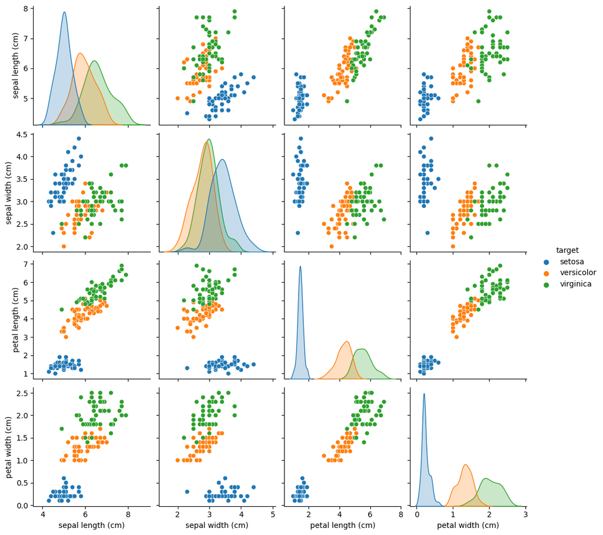

```python
import pandas as pd
df = pd.DataFrame(iris.data, columns=iris.feature_names)
df['target'] = iris.target_names[iris.target]
import matplotlib.pyplot as plt
import seaborn as sns
sns.pairplot(df, hue='target')
```

However, versicolor and virginica are not completely separated in any of the scatter plots. From the scatterplots, it seems difficult to completely separate versicolor and virginica, but let us consider this as a model and make a prediction.

```python
df2 = df[(df['target']=='versicolor') | (df['target']=='virginica')]
df2.head()
```

|  | sepal length (cm) | sepal width (cm) | petal length (cm) | petal width (cm) | target |
| --- | --- | --- | --- | --- | --- |
| 50 | 7.0 | 3.2 | 4.7 | 1.4 | versicolor |
| 51 | 6.4 | 3.2 | 4.5 | 1.5 | versicolor |
| 52 | 6.9 | 3.1 | 4.9 | 1.5 | versicolor |
| 53 | 5.5 | 2.3 | 4.0 | 1.3 | versicolor |
| 54 | 6.5 | 2.8 | 4.6 | 1.5 | versicolor |

The explanatory variables (features) and response variables (varieties) are extracted from the iris data frame, and each is further divided into two parts, one for training and the other for testing. Since the units of the four features are the same and there is no extreme difference in size, standardization is omitted here.

```python
# 説明変数を用意（target列を落とす）
X = df2.drop('target', axis=1)
# versicolorをクラス0, virginicaをクラス1とする
y = df2['target'].map({'versicolor': 0, 'virginica': 1})
# データを分割# 80%のデータを学習データに、20%をテストデータにする
from sklearn.model_selection import train_test_split
X_train, X_test, y_train, y_test = train_test_split(X, y, test_size = 0.2, random_state = 0)
```

Let's run the logistic regression as a Lasso regression: l1 for the penalty argument of `LogisticRegression()` will run a Lasso regression, and l2 will run a Ridge regression. Here, do not think too much about the solver argument.

```python
from sklearn.linear_model import LogisticRegression
model = LogisticRegression(penalty='l1',
    solver='liblinear', C=1.1)
model.fit(X_train, y_train)
```

```
LogisticRegression(C=1.1, penalty='l1', solver='liblinear')
```

Here, inside the Logistic regression, the probability that an individual is a virginica is calculated. In general, if this probability is greater than 0.5, the individual is considered 1 'virginica'; otherwise, it is considered 0 'versicolor'.

Let us try to make a prediction from the test data.

```python
y_pred = model.predict(X_test)
y_pred
```

```
array([0, 1, 0, 1, 1, 1, 0, 1, 1, 1, 1, 1, 1, 0, 0, 0, 1, 0, 1, 0])
```

By the way, logistic regression is a model that predicts (i.e., classifies) the label of which of two values the response variable will be. The MSE, explained earlier, is an appropriate indicator when the response variable is numeric, as in the regression problem. In this case, how can we determine the accuracy of the prediction? In the problem of classification, one way to check the accuracy of the prediction would be to determine, for example, the percentage of correct classifications out of the total. For example, if there are 20 individuals in the test data and the training model correctly predicts 18 of them, the percentage of correct answers is 18/20=0.9.

In machine learning tasks for binary classification, a confusion matrix is often created as a table to check the percentage of correct answers.

```python
from sklearn.metrics import confusion_matrix
cm = confusion_matrix(y_true=y_test, y_pred=y_pred.round())
labels = ['versicolor', 'virginica']
cm = pd.DataFrame(cm, columns=labels, index=labels)
cm
```

|  | versicolor | virginica |
| --- | --- | --- |
| versicolor | 8 | 2 |
| virginica | 0 | 10 |

The output is confusing, but can be rewritten as follows

[output not shown]

The actual (true) labels are placed in the rows and the predicted labels in the columns, with the corresponding number of pieces recorded. Negative and Positive, which are appended to the cells, correspond to 0 and 1, respectively. In the case of this analysis, 0 corresponds to versicolor and 1 to virginica; True Negative means that an individual predicted as 0 is actually 0, while False Positive means that an individual predicted as 1 is actually 0. True Negative and True Positive indicate the number of individuals for whom the prediction was correct. In other words, Lasso regression correctly predicted 18 out of 20 individuals. This percentage is called accuracy, which is one of the criteria used to measure the accuracy of predictions in classification.

```python
from sklearn.metrics import accuracy_score
accuracy_score(y_test, y_pred)
```

```
0.9
```

Another commonly used measure is the Area Under Curve (AUC), which corresponds to the area to the lower right of the receiver operating characteristic (ROC) curve (which in this example is jagged like a staircase) in the graph below. In this case, if the area of the entire plot is 1.0, the closer the area below the curve to the right is to 1.0, the higher the prediction accuracy of the model.

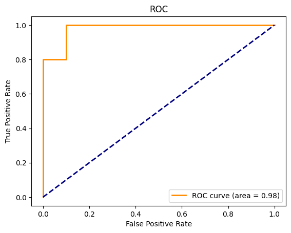

```python
import matplotlib.pyplot as plt
y_score = model.predict_proba(X_test)[: ,1]
from sklearn.metrics import roc_curve, auc
fpr, tpr,thred = roc_curve(y_test, y_score)
roc_auc = auc(fpr, tpr)
plt.figure()
lw = 2
plt.plot(fpr, tpr, color='darkorange',lw=lw, label='ROC curve (area = %0.2f)' % roc_auc)
plt.plot([0, 1], [0, 1], color='navy', lw=lw, linestyle='--')
plt.xlabel('False Positive Rate')
plt.ylabel('True Positive Rate')
plt.title('ROC')
plt.legend(loc="lower right")
```

```python
from sklearn.metrics import roc_auc_score
roc_auc_score(y_test, y_pred)
```

```
0.9
```

## ROCとAUC

Key Points of Today's Lecture

[video not shown]

In the regression, the response variable was numeric and MSE was used as an assessment of accuracy. On the other hand, in logistic regression, the response variable is binary categorical, so MSE cannot be used for evaluation. Binary classification is evaluated based on the number of matches between model predictions and response values.

There are various possible levels of binary categories, such as "support" and "dissupport", "pass" and "fail", or "success" and "failure". It is often expressed as "negative (negative)".

In binary classification, whether or not the level of an observed value is positive is judged based on the probability obtained from the model. It would be easy to simply judge that an observation is positive if the probability is greater than 0.5, otherwise negative. This is called a threshold.

If the threshold is set low (say 0.1), more observations will be judged positive. Conversely, if the threshold is 0.9, most may be judged as negative. If the threshold is set to 1.0, then everything will be judged as negative.

For example, even if 3 out of 10 individuals are actually negative, if the threshold is 1.0, the predictive model will judge all 10 to be negative (first column in the table below).

|  | Negative 0 in prediction | Positive 1 in prediction |
| --- | --- | --- |
| actually negative 0 | (TN) 3 | (FP) 0 |
| actually positive 1 | (FN) 7 | (TP) 0 |

By the way, the percentage of positive observations (7 in the example above) that are correctly determined by the model is called sensitivity or recall. In the table above, the sensitivity is $0/(7+0)= 0$ (Breakdown of positive rows).

On the other hand, the percentage of observations that are actually negative (three in the example above) that the model correctly classifies as negative is called specificity. in the table above $3/(0 + 3) = 1$ (breakdown of negative rows).

By the way, the percentage of actually negative observations (three in the example above) that are erroneously classified as positive is called the false positive rate. $0 /(0 +3) = 0$

Although the specificity is numerically 1.0, the model fails to correctly identify positive observations. In addition, the total number of cases (the number of response variables) is the denominator, and the numerator is the sum of the number of positives correctly classified as positives and the number of negatives correctly classified as negatives. is called Accuracy. In this case,

$\frac{0+3}{0 + 0 + 7 + 3}$

We want to reduce the rate of erroneously determined positives, but at the same time we want to adopt a model that can correctly determine positive observations that are actually positive. Therefore, we create an ROC (Receiver Operating Characteristic) curve to confirm changes in specificity and sensitivity when changing the threshold.

The ROC (Receiver Operating Characteristic) curve is a graph in which the horizontal axis represents the false positive rate (1-specificity) and the vertical axis represents the sensitivity (true positive rate).

For example, when using a threshold (not necessarily 0.0 because it depends on the analysis data) that makes the false positive rate 0 (the left end of the ROC curve above, the origin), 80% of the positive data in this data are correctly classified as positive (0.8 on the vertical axis). Conversely, when the threshold value (not necessarily 1.0 because it depends on the analysis data) is used to judge all negative data as positive, all positive data are judged to be positive, so the true positive rate on the vertical axis is is also 1.0.

ROC is a graph representing this change. A good model has a small false-positive rate but a high sensitivity or true-positive rate. This can be understood graphically as the area to the right of the curve. That is AUC (Area Under the Curve). The closer the AUC is to 1.0, the better the predictive performance of the model.

In Python, AUC can be calculated as follows.

```python
from sklearn.metrics import roc_auc_score
roc_auc_score(y_test, y_pred)
```

```
0.9
```

## Decision Trees

The above explanation has focused on regression, but from this point on, other machine learning methods will be briefly described. First, we will discuss decision trees.

Key Points of Today's Lecture

[video not shown]

A decision tree is a method of repeating classification by applying conditions to the entire data.

Going back to the top again, if the petal length size exceeds 2.5 cm, the following conditions will determine if the petal width is less than 1.8 and the species is versicolor. Go left according to the criteria of less than 1.8. However, at this stage, one of the versicolors will be omitted from the judgment. In addition, 5 individuals of the virginica species were misidentified. Go back one step up again, and if the petal width is 1.8 or more, move to the lower right. As a result, 45 virginica species are correctly identified, but 1 versicolor species is misidentified.

The concept of Gini impurity is applied in the classification of decision trees.

$$ I_G (t) = 1 - \sum_{i=1}^{c} p (i|t)^2 $$

Simply put, here $ p (i|t)^2$ is the category (level) $c$ at a node (t) in the decision tree is correctly classified.

A mixture of multiple levels of categories (three types of iris in the example above) is impure, and three completely separated into three groups by cultivar is pure. Impurity is expressed in terms of Gini impurity and entropy.

Let me explain with a very simple example. Suppose that the following data is obtained as to whether or not a person went to university.

Let me explain with a very simple example. Suppose that the following data is obtained as to whether or not a person went to university.

| 学生 ID | 天気 | 気温 | 大学へ行ったか |
| --- | --- | --- | --- |
| No.1 | 晴 | 高 | Yes |
| No.2 | 晴 | 低 | No |
| No.3 | 晴 | 高 | Yes |
| No.4 | 晴 | 中 | Yes |
| No.5 | 晴 | 低 | No |
| No.6 | 晴 | 高 | No |
| No.7 | 雨 | 高 | No |
| No.8 | 雨 | 低 | No |
| No.9 | 雨 | 中 | No |
| No.10 | 雨 | 高 | Yes |
| --------- | ------ | ------ | ---------------- |

Here, first of all, looking at whether or not they went to university, the ratio is 4 to 6, but this is expressed as follows in terms of impurity.

$$ 1 - {(\frac{4}{10})^2 + (\frac{6}{10})^2} = 0.48 $$

This Gini impurity is taken as a starting point.

Next, there are 6 cases where the weather is fine, and in this case, there are 3 cases for whether or not you went to university.

If the weather was rainy, there was 1 case of going to university and 3 cases of not going to college.

By the way, if you install the software called graphVis and execute the following code, the graph will be displayed even in Python. In this case, from X[0] to X[3] in the graph are the sepal length, sepal width, petal length, and petal width.

```python
!pip install pydotplus six
```

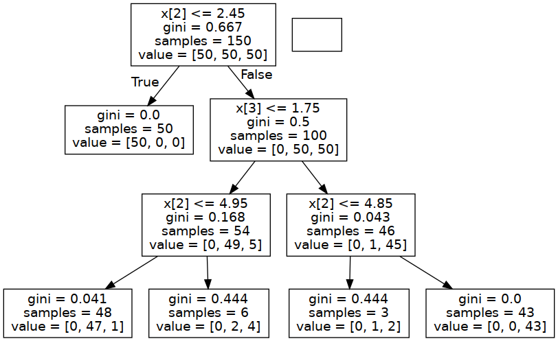

```python
import six
from six import StringIO
import sys
sys.modules['sklearn.externals.six'] = six
from sklearn import tree
clf = tree.DecisionTreeClassifier(max_depth=3)
clf = clf.fit(iris.data, iris.target)
predicted = clf.predict(iris.data)
sum(predicted == iris.target) / len(iris.target)
tree.export_graphviz(clf, out_file="tree.dot",
                         feature_names=iris.feature_names,
                         class_names=iris.target_names,
                         filled=True, rounded=True)
import pydotplus
dot_data = StringIO()
tree.export_graphviz(clf, out_file=dot_data)
graph = pydotplus.graph_from_dot_data(dot_data.getvalue())
from IPython.display import Image
Image(graph.create_png())
```

External site: Wikipedia: Decision tree pruning

Decision trees can create graphs that are intuitive and easy to understand. In addition, preprocessing such as standardization is not required (data scale does not affect analysis). Therefore, although it is widely used in the data science field, it has the drawback of being prone to overfitting, which will be described later. Therefore, at present, a large number of decision trees are created and the model is adjusted based on the average or majority vote. He calls this method ensemble learning (random forest).

[video not shown]

## support vector machine

Support vector machines have been applied in various fields as the most accurate prediction method for a while. Since the spread of deep learning, although the number of cases where it is applied has decreased, depending on the problem, it is a method that is more efficient than deep learning and can achieve the same level of accuracy.

The following video will help you understand how the support vector machine performs classification.

Key Points of Today's Lecture

[video not shown]

Let's run a support vector machine in Python using the iris data as an example.

As seen in the video, in binary classification problems, there are cases where linearly separable is possible and cases where linear separation is not possible. Intuitively, linear separation means that there is a line or plane between two groups.

There are three varieties in the iris data, some of which can be linearly separated and others which cannot. First, let's check it with a diagram. Start by loading the data.

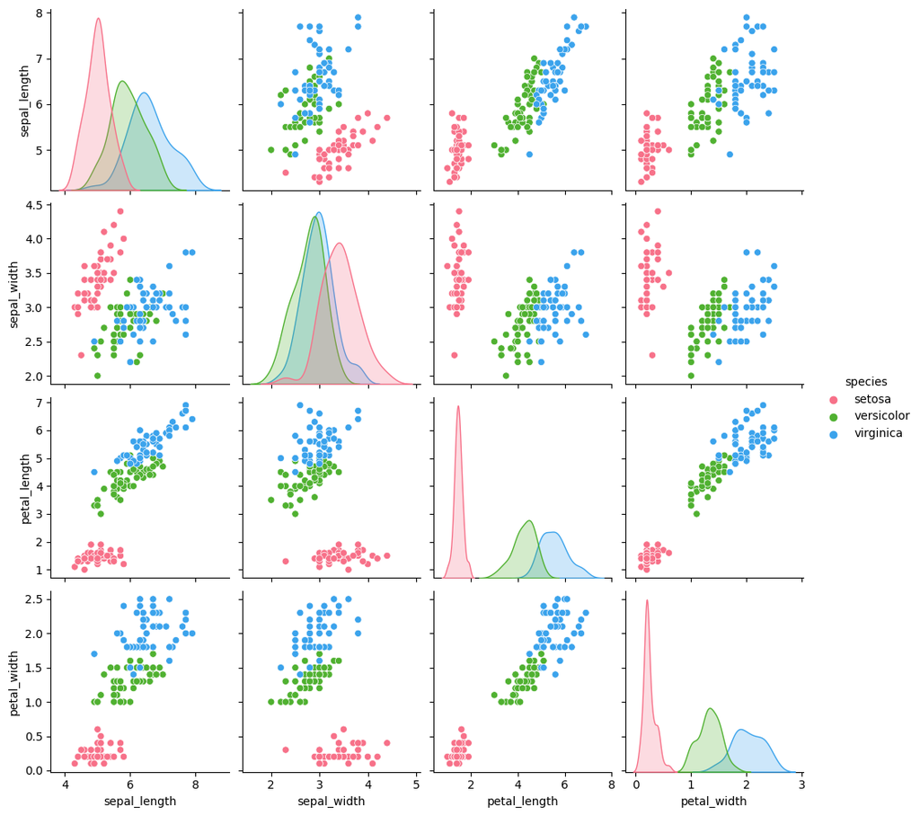

```python
from sklearn.datasets import load_iris
import seaborn as sns
iris_dataset = sns.load_dataset("iris")
sns.pairplot(iris_dataset, hue='species', palette="husl")
```

From this figure, it seems that the setosa cultivar represented by the red dot can be separated from the other cultivars by drawing a line. However, it seems difficult to completely separate versicolor and virginica by a line segment. Let's divide it into two types, setosa and versicolor, and solve the problem of separating these two types with a support vector machine. Let's start with data preparation. In order to make the graph easier to understand, only two cultivars are extracted from iris, and the feature values are sepal length and sepal width.

```python
import pandas as pd
df = pd.DataFrame(iris.data, columns=iris.feature_names)
df['target'] = iris.target_names[iris.target]
df2 = df[(df['target']=='versicolor') | (df['target']=='setosa')]
```

```python
# 説明変数を用意（もとデータの１，２列、`sepal length`と`sepal width`のみ使う）
X = df2.iloc[:,:2]
# setosaをラベル 0, versicolorをラベル1とする
y = df2['target'].map({'setosa': 0, 'versicolor': 1})
# データを分割# 80%のデータを学習データに、20%をテストデータにする
from sklearn.model_selection import train_test_split
X_train, X_test, y_train, y_test = train_test_split(X, y, test_size = 0.2, random_state = 0)
```

```python
from sklearn.preprocessing import StandardScaler
stdsc = StandardScaler()
X_train_std = stdsc.fit_transform(X_train)
X_test_std = stdsc.transform(X_test)
```

```python
from sklearn.svm import SVC
svm = SVC(kernel = 'linear')
svm.fit(X_train_std,y_train)
```

```
SVC(kernel='linear')
```

The result of learning with training data is predicted using the explanatory variables of the training data, and it is visualized whether the two breeds are separated by a line segment.

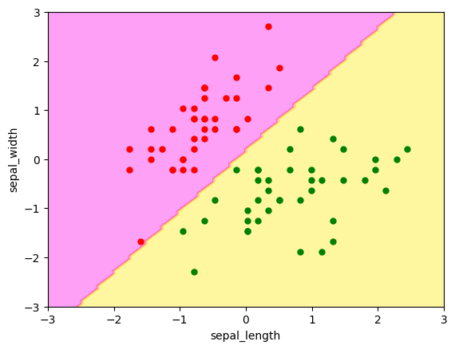

```python
import numpy as np
x0 = np.linspace(-3.0, 3.0, 100)
x1 = np.linspace(-3.0, 3.0, 100)
x0, x1 = np.meshgrid(x0, x1)
X_ = np.c_[x0.ravel(), x1.ravel()]
y_pred = svm.predict(X_).reshape(x0.shape)
y_decision = svm.decision_function(X_)
plt.contourf(x0, x1, y_pred, cmap='spring', alpha=0.4)
# plt.contourf(x0, x1, y_decision, alpha=0.2)
plt.plot(X_train_std[:, 0][y_train==0], X_train_std[:, 1][y_train==0], "ro", ms=5)
plt.plot(X_train_std[:, 0][y_train==1], X_train_std[:, 1][y_train==1], "go", ms=5)
plt.xlabel("sepal_length")
plt.ylabel("sepal_width")
```

In the above figure, the upper left and lower right seem to separate the individual species. By the way, let's predict the test data using the learning result and check the accuracy rate.

```python
y_pred = svm.predict(X_test_std)
from sklearn.metrics import accuracy_score
accuracy_score(y_test, y_pred)
```

```
1.0
```

It is the same as the result that can be read from the above figure, and it can be confirmed that the cultivar can be predicted perfectly (However, since this is a small sample data, a complete correct answer can be obtained. If you get an accuracy rate of , you should suspect that there is a problem in some procedure). Next, let us introduce an example of nonlinear separation. In the case of data whose explanatory variables cannot be linearly divided, the support vector machine creates new feature values from the original explanatory variables and performs classification based on these new feature values, as was the case with the video. However, in reality, creating a new feature value requires a cost such as calculation. Support vector machines avoid this by using a trick (called a kernel trick).

External Site: Wikipedia: Kernel Method

```python
from sklearn.svm import SVC
svm = SVC(kernel = 'rbf')
svm.fit(X_train_std,y_train)
```

```
SVC()
```

Prediction is made using explanatory variables of training data on the result of learning with training data, and it is confirmed by visualization whether the two breeds are separated.

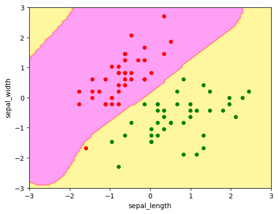

```python
import numpy as np
x0 = np.linspace(-3.0, 3.0, 100)
x1 = np.linspace(-3.0, 3.0, 100)
x0, x1 = np.meshgrid(x0, x1)
X_ = np.c_[x0.ravel(), x1.ravel()]
y_pred = svm.predict(X_).reshape(x0.shape)
y_decision = svm.decision_function(X_)
plt.contourf(x0, x1, y_pred, cmap='spring', alpha=0.4)
# plt.contourf(x0, x1, y_decision, alpha=0.2)
plt.plot(X_train_std[:, 0][y_train==0], X_train_std[:, 1][y_train==0], "ro", ms=5)
plt.plot(X_train_std[:, 0][y_train==1], X_train_std[:, 1][y_train==1], "go", ms=5)
plt.xlabel("sepal_length")
plt.ylabel("sepal_width")
```

In this figure you can see that the separation is not linear. Also, only one red dot in the lower left is misclassified. Let's predict the test data with this learning model.

```python
y_pred = svm.predict(X_test_std)
from sklearn.metrics import accuracy_score
accuracy_score(y_test, y_pred)
```

```
1.0
```

### SVM hyperparameters

In the final analysis, we made one wrong prediction on the training data. Support vector machines actually have a hyperparameter C that specifies how much misclassification they tolerate. Increasing C reduces misclassification on the training data, but reduces generalization performance. In other words, it becomes overlearning.

The Python function SVM() used here has a default value of 1.0 in C. For example, let's assign 10 to C and classify again.

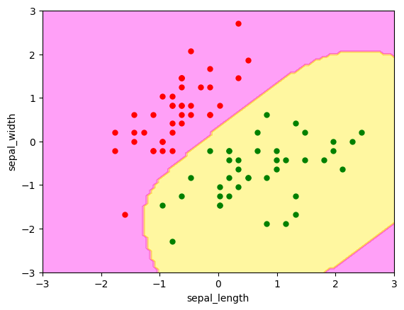

```python
svm = SVC(kernel = 'rbf', C=10)
svm.fit(X_train_std,y_train)
x0 = np.linspace(-3.0, 3.0, 100)
x1 = np.linspace(-3.0, 3.0, 100)
x0, x1 = np.meshgrid(x0, x1)
X_ = np.c_[x0.ravel(), x1.ravel()]
y_pred = svm.predict(X_).reshape(x0.shape)
y_decision = svm.decision_function(X_)
plt.contourf(x0, x1, y_pred, cmap='spring', alpha=0.4)
# plt.contourf(x0, x1, y_decision, alpha=0.2)
plt.plot(X_train_std[:, 0][y_train==0], X_train_std[:, 1][y_train==0], "ro", ms=5)
plt.plot(X_train_std[:, 0][y_train==1], X_train_std[:, 1][y_train==1], "go", ms=5)
plt.xlabel("sepal_length")
plt.ylabel("sepal_width")
```

It can be seen that the training data is also well classified.

## deep learning

Finally, let's talk about deep learning. As for deep learning, it would be a good idea to watch the following video first.

Key Points of Today's Lecture

[video not shown]

Deep learning is also one of machine learning. By the way, in contrast to deep learning, there are other machine learning methods called shallow learning. Simply put, in general machine learning We predicted the response variables from the explanatory variables as $y = \, a_1 \, x_1, \, a_2 \, x_2 \dots a_n \, x_n$

On the other hand, in deep learning, there is a "layer" between $y$ and $a_1 \, x_1, \, a_2 \, x_2 \dots a_n \, x_n$ .

After learning $a_1 \, x_1, \, a_2 \, x_2 \dots a_n \, x_n$ , set the middle layer and (simplified) and continue the parameter estimation $a_{2,1} , a_{2,2} \,\dots a_{2,n}$ .

General machine learning does not have this layer, or if there is only one or two layers, deep learning has many layers (tens, hundreds, etc.) , the final prediction is output.

Deep learning is almost a standard analytical method in fields such as image recognition and automatic translation, and its applications are progressing (we already have many benefits).

In programming languages such as Python and R, there are many libraries that can easily execute deep learning, and if you just try image recognition, you can achieve it by writing relatively simple code. Interested people should search with keywords such as keras and pyTorch. In addition, Google Colaboratory has published a Jupyter Notebook that can perform deep learning in the cloud. Plus, it's free if you're just trying out small-scale analytics (user info and credit card registration required). However, if you carelessly use it for a long time, Google will send you an invoice at a later date, so be careful.

Even though many tools for deep learning have been released, it takes a large amount of input ( data), and specifying layers in the learning model, etc., requires trial and error. In addition, since deep learning requires a large amount of calculation, additional hardware such as a GPU (graphics card) is required. That said, I have a lot of data and I want to sort this out. However, deep learning is a very powerful tool when it is not necessary to understand the grounds and reasons for classification in detail.